# 0219

```r
#####
# set up the environment
#####
# load packages
library(rethinking)
options(mc.cores = parallel::detectCores())
rstan_options(auto_write = TRUE)

# adjust the plot region for viewing on the projector in class
options(repr.plot.height=5)
```

```
rstan (Version 2.18.2, GitRev: 2e1f913d3ca3)
For execution on a local, multicore CPU with excess RAM we recommend calling
options(mc.cores = parallel::detectCores()).
To avoid recompilation of unchanged Stan programs, we recommend calling
rstan_options(auto_write = TRUE)
rethinking (Version 1.59)
```

## Multinomial logistic regression

We'll be using the US microdata sample that we have seen before to predict the association between income and marital status.

```r
# download the data
d <- read.csv("https://mcmahanp.github.io/soci620/data/USincome_subset_2016.csv")
# look at it
head(d)
```

| id | family_size | children_in_hh | female | age | marital_status | times_married | race | hispanic | hispanic_origin | health_ins | health_ins_priv | health_ins_employer | in_school | ed_highschool | ed_college | income | poverty | occ_income | log_income |
| --- | --- | --- | --- | --- | --- | --- | --- | --- | --- | --- | --- | --- | --- | --- | --- | --- | --- | --- | --- |
| 1545 | 2 | 0 | 1 | 93 | Married, spouse present | 1 | White | 0 | Not Hispanic | 1 | 1 | 0 | 0 | 1 | 0 | 22800 | FALSE | NA | 10.034516 |
| 2532 | 3 | 0 | 0 | 29 | Never married/single | 0 | White | 0 | Not Hispanic | 1 | 1 | 1 | 0 | 1 | 0 | 22000 | FALSE | 38 | 9.998798 |
| 2540 | 1 | 0 | 1 | 87 | Widowed | 1 | White | 0 | Not Hispanic | 1 | 1 | 0 | 0 | 1 | 0 | 16000 | NA | NA | 9.680344 |
| 3654 | 6 | 1 | 1 | 21 | Never married/single | 0 | White | 0 | Not Hispanic | 1 | 1 | 1 | 1 | 1 | 0 | 7000 | FALSE | 18 | 8.853665 |
| 3825 | 3 | 0 | 1 | 52 | Separated | 1 | White | 0 | Not Hispanic | 0 | 0 | 0 | 0 | 0 | 0 | 20000 | FALSE | 23 | 9.903488 |
| 6736 | 3 | 0 | 0 | 16 | Never married/single | 0 | White | 0 | Not Hispanic | 1 | 1 | 1 | 1 | 0 | 0 | 3000 | FALSE | 24 | 8.006368 |

What categories exist for marital status?

```r
summary(d$marital_status)
```

**Divorced**

416

**Married, spouse absent**

90

**Married, spouse present**

1576

**Never married/single**

965

**Separated**

67

**Widowed**

199

That's more fine-grained than we want. We can make four categories from these six by putting "Divorced" and "Separated" in one category and "Married, spouse absent" and "Married, spouse present" in another category.

At the same time, let's code the new variable so that married respondents are the reference category. (Choosing a reference category is arbitrary as far as the model is concerned, so it should be based on your specific research question.)

```r
d$ms <- NA
d$ms[d$marital_status=="Never married/single"] <- 2
d$ms[d$marital_status=="Married, spouse absent"] <- 1
d$ms[d$marital_status=="Married, spouse present"] <- 1
d$ms[d$marital_status=="Divorced"] <- 3
d$ms[d$marital_status=="Separated"] <- 3
d$ms[d$marital_status=="Widowed"] <- 4
```

When recoding a categorical variable it is *always* a good idea to look at a cross-tabulation to make sure you made no mistakes.

```r
table(d$marital_status, d$ms)
```

```
                             1    2    3    4
  Divorced                   0    0  416    0
  Married, spouse absent    90    0    0    0
  Married, spouse present 1576    0    0    0
  Never married/single       0  965    0    0
  Separated                  0    0   67    0
  Widowed                    0    0    0  199
```

Define the model using the `dcategorical` and `softmax` functions.

```r
# the order of arguments to dcategorical determines which
# category is which
m <- alist(
    ms ~ dcategorical(softmax(0,s_s,s_d,s_w)),
    s_s <-  a_s + b_s*log_income,
    s_d <-  a_d + b_d*log_income,
    s_w <-  a_w + b_w*log_income,
    c(a_s,b_s,a_d) ~ dnorm(0,2),
    c(b_d,a_w,b_w) ~ dnorm(0,3)
)
```

Fittinig these models can be pretty slow, even with `map()`. Giving it some reasonable start values can help somewhat.

```r
# define reasonable start values
#
# To get this to run more quickly in class I am giving it
# VERY UNREASONABLE start values. These are based on having
# run the model before. When you run models you should set
# these to less specific numbers, like 0.
st <- list(a_s=5.2,b_s=-.6,a_d=0.5,b_d=-.2,a_w=1.8,b_w=-.4)

fit <- map(m,data=d,start=st)
precis(fit,prob=.9)
```

```
     Mean StdDev  5.0% 95.0%
a_s  5.18   0.37  4.57  5.79
b_s -0.57   0.04 -0.63 -0.51
a_d  0.46   0.48 -0.32  1.24
b_d -0.16   0.05 -0.24 -0.09
a_w  1.79   0.62  0.77  2.81
b_w -0.39   0.06 -0.49 -0.28
```

Aside from the sign and confidence of the estimates, it is very hard to interpret these coefficients on their own. We can say that income is negatively associated with being single, divorced, or widowed *in comparison with* being married. That is, as income increases, the model predicts a higher probability of being married rather than single, of being married rather than divorced, and of being married rather than widowed.

We can get a better idea of the specific relationships by predicting outcomes for specific sets of covariates. We'll start by comparing people that make \$10,000 per year to people that make \$100,000 per year.

```r
# get the predicted coefficients
cf <- coef(fit)
cf
```

**a_s**

5.17804062091

**b_s**

-0.570698975070218

**a_d**

0.459796750135133

**b_d**

-0.164920362799189

**a_w**

1.78992143520494

**b_w**

-0.385276281125834

```r
# define a simple softmax function
sm <- function(s){
    exp(s)/sum(exp(s))
}

# 10k
s1 <- c(
    0,
    cf['a_s'] + cf['b_s']*log(10000),
    cf['a_d'] + cf['b_d']*log(10000),
    cf['a_w'] + cf['b_w']*log(10000)
)
s1
#p1 <- sm(s1)
p1 <- softmax(s1[1],s1[2],s1[3],s1[4])
names(p1) <- c('married','single','divorced','widowed')
p1

# 100k
s2 <- c(
    0,
    cf[1] + cf[2]*log(100000),
    cf[3] + cf[4]*log(100000),
    cf[5] + cf[6]*log(100000)
)
p2 <- sm(s2)
names(p2) <- c('married','single','divorced','widowed')
p2
```

**1**

0

**a_s**

-0.0782911894246547

**a_d**

-1.0591759255152

**a_w**

-1.75860425121317

**married**

0.409211896314861

**single**

0.378396245980603

**divorced**

0.141890719490353

**widowed**

0.0705011382141828

**married**

0.642416804577222

**single**

0.159630725050869

**divorced**

0.152370983313341

**widowed**

0.0455814870585677

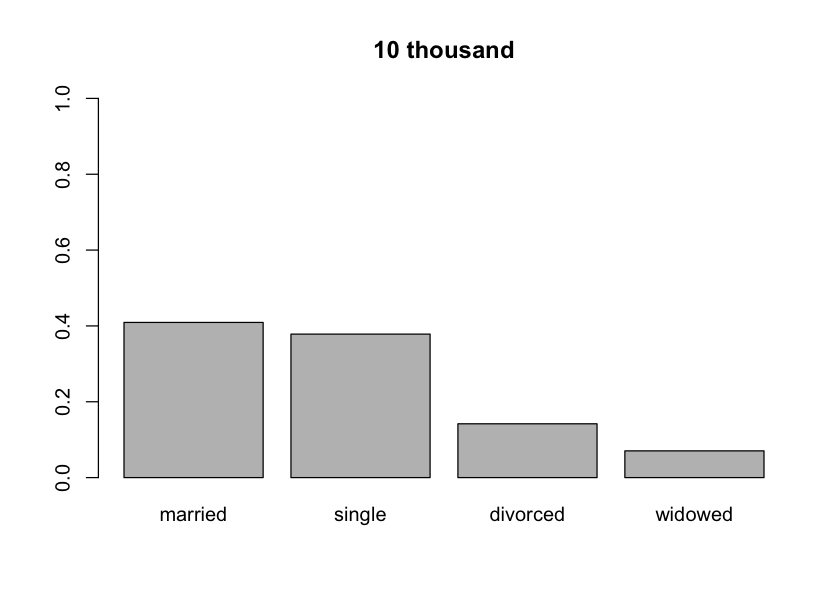

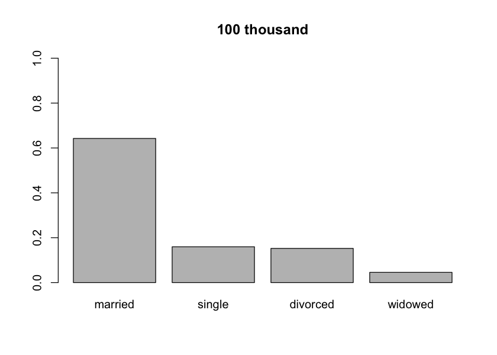

```r
# visualizations can help a lot here
barplot(p1,main='10 thousand',ylim=c(0,1))
barplot(p2,main='100 thousand',ylim=c(0,1))
```

The `link` function makes it straightforward to include uncertainty in these estimates.

```r
# simulate 2000 draws from the posterior
nsamp <- 2000
post1 <- link(fit,data=list(log_income=log(10000)),n=nsamp)
post2 <- link(fit,data=list(log_income=log(100000)),n=nsamp)
# post1 now has 2000 posterior draws of s_w, s_d, and s_s,
# conditional on log_income=log(10000)
# post2 has the same data, but conditional on the much higher income
names(post1)
head(post1$s_s)
```

```
[ 2000 / 2000 ]
[ 2000 / 2000 ]
```

1. 's_w'

2. 's_d'

3. 's_s'

| -0.15323196 |
| --- |
| -0.05795250 |
| -0.13539764 |
| -0.11069857 |
| -0.08449753 |
| -0.04043394 |

```r
# use sapply to apply the softmax for each sample for each of our cases
# 10k
#post_prob1 <- softmax(0,post1$s_s,post1$s_d,post1$s_w)
post_prob1 <- sapply(1:nsamp, function(i){
    sm(c(0, post1$s_s[i], post1$s_d[i], post1$s_w[i]))
})
# 100k
post_prob2 <- sapply(1:nsamp, function(i){
    sm(c(0, post2$s_s[i], post2$s_d[i], post2$s_w[i]))
})

# each of these post_prob variables now holds 2000 posterior samples
# (columns) of the probability of each of the 4 variables (rows)
dim(post_prob1)
```

1. 4

2. 2000

```r
# get 90% credible intervals for each
ci1 <- apply(post_prob1,1,PI,prob=.9)
ci2 <- apply(post_prob2,1,PI,prob=.9)
ci1;ci2
```

| 5% | 0.3899398 | 0.3609569 | 0.1296675 | 0.06198924 |
| --- | --- | --- | --- | --- |
| 95% | 0.4275091 | 0.3959449 | 0.1551704 | 0.08022195 |

| 5% | 0.6205678 | 0.1461123 | 0.1370188 | 0.03743560 |
| --- | --- | --- | --- | --- |
| 95% | 0.6623187 | 0.1742715 | 0.1692958 | 0.05487018 |

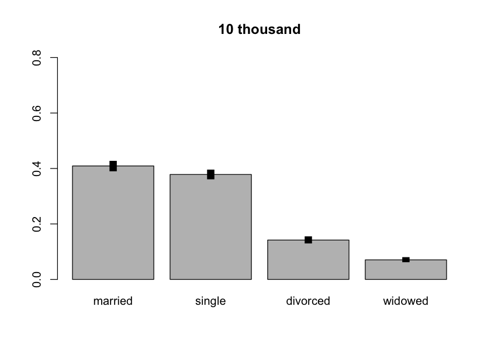

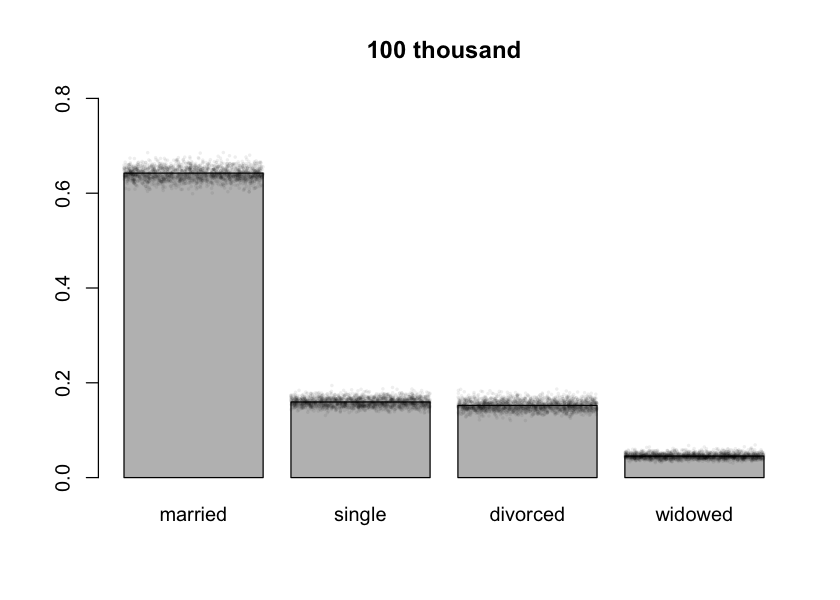

```r
# bar charts again, but let's add credible intervals
# (barplot() creates the plot, but it also returns
# the x coordinates of the bars. This is useful if
# you want to add on to a bar chart like we do.)
bp_x <- barplot(p1,main='10 thousand',ylim=c(0,0.8))
for(i in 1:4){
    x <- bp_x[i]
    lines(x=c(x,x), y=c(ci1[1,i],ci1[2,i]),lwd=10,lend='butt')
}

# same for 100k
bp_x <- barplot(p2,main='100 thousand',ylim=c(0,0.8))
for(i in 1:4){
    x <- bp_x[i]
    # instead of a line, we can also just plot a cloud of points
    points(jitter(rep(x,nsamp),amount=.5),post_prob2[i,],pch=16,cex=.4,col='#00000011')
}
```

For an even more informative visualization, we can plot the probabilities of each outcome for a wide range of possible income values.

```r
# generate samples from the posterior for every point on grid
# of potential log incomes
grid <- seq(log(1000),max(d$log_income),length.out=456)
post <- link(fit,data=list(log_income=grid),n=nsamp)
# look at the output to see its format
names(post)
dim(post[[1]])
# it is a list with three items, one for each of the "s" parameters
# each one has 2000 samples (rows) at each of the 456 grid points (columns)
```

```
[ 2000 / 2000 ]
```

1. 's_w'

2. 's_d'

3. 's_s'

1. 2000

2. 456

```r
# calculate posterior median and 90%-interval for probability
# (vapply is like sapply, but you tell it the shape of the
# result of each iteration. This is necessary here because)
# each loop through grid returns a 3x4 matrix)
ppost <- vapply(1:length(grid),function(i){ # for each point on the grid
    # make a matrix of just the s values for this level of income
    ssamp <- cbind(0,post$s_s[,i],post$s_d[,i],post$s_w[,i])
    # use sm to convert to probabilities
    psamp <- apply(ssamp,1,sm)
    # get the 0.05, 0.5, and 0.95 quantile
    # this gives us the 90% interval and the median
    prange <- apply(psamp,1,quantile,probs=c(0.05,0.5,0.95))
},matrix(0.0,nrow=3,ncol=4))
dim(ppost)
ppost[,,5]
```

1. 3

2. 4

3. 456

| 5% | 0.1642005 | 0.5911645 | 0.07597362 | 0.05796465 |
| --- | --- | --- | --- | --- |
| 50% | 0.1912665 | 0.6326966 | 0.09501555 | 0.07816965 |
| 95% | 0.2202591 | 0.6718852 | 0.11904220 | 0.10464073 |

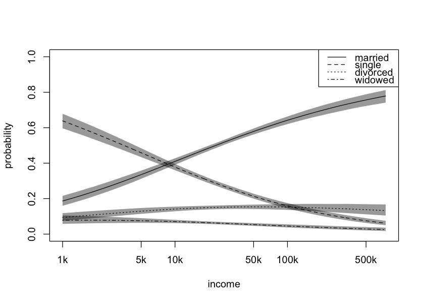

```r
# make  aplot of each individual predicted probability along with 90% interval
plot(NA,xlim=range(grid),ylim=c(0,1),xlab='income',ylab='probability',xaxt='n')
# create an x axis with meaningful values of income
inc_vals <- c(1e3,5e3,1e4,5e4,1e5,5e5)
inc_labels <- c('1k','5k','10k','50k','100k','500k')
axis(1,at=log(inc_vals),labels=inc_labels)
for(i in 1:4){# four categories
    # a line for the median value
    lines(grid,ppost[2,i,],lty=i)
    # a polygon for the 90% interval
    polygon(
        c(grid,rev(grid)),
        c(ppost[1,i,],rev(ppost[3,i,])),
        col='#00000066',
        border=NA
    )
}
legend('topright',lty=1:4,legend=c('married','single','divorced','widowed'))
```

Another useful plot is a 'stacked' probability plot. It is better at showing total proportions, but is worse at showint the uncertainty in our posterior estimates. We can use the same simulated data from the previous plot to make a stacked plot.

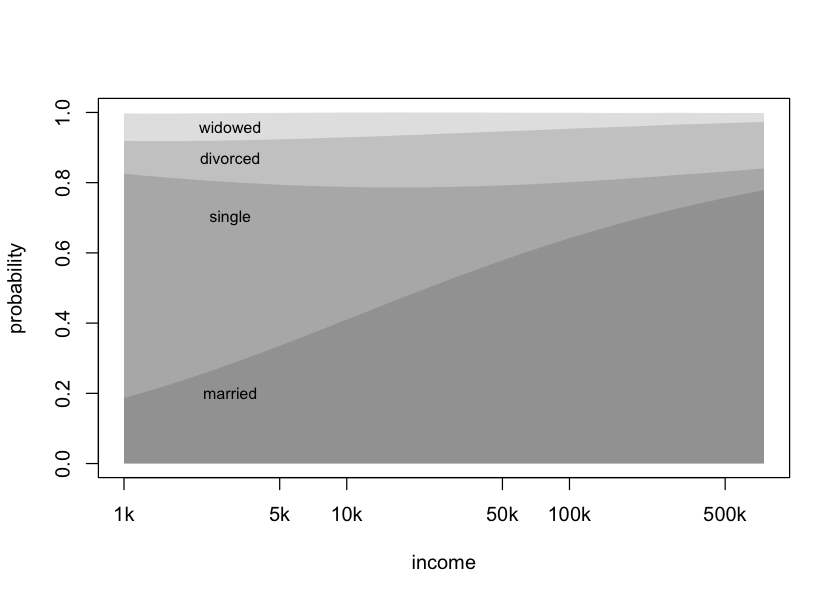

```r
# make  aplot of each individual predicted probability along with 90% interval
plot(NA,xlim=range(grid),ylim=c(0,1),xlab='income',ylab='probability',xaxt='n')
# create an x axis with meaningful values of income
inc_vals <- c(1e3,5e3,1e4,5e4,1e5,5e5)
inc_labels <- c('1k','5k','10k','50k','100k','500k')
axis(1,at=log(inc_vals),labels=inc_labels)
# define colors
cols <- c('red','blue','orange','pink')
for(i in 1:4){# four categories
    # get the cumulative probability
    if(i==1){
        # different logic for the first row
        cum_p <- ppost[2,i,]
    }else{
        cum_p <- apply(ppost[2,1:i,],2,sum)
    }
    # draw a polygon from the bottom up to our values
    # note, this will only work with a color that has
    # some transparency. otherwise the final polygon will
    # simply cover the rest.
    polygon(
        c(grid,rev(grid)),
        c(cum_p,rep(0,length(grid))),
        col='#00000022',
        border=NA
    )
}
# placement of labels takes some trial and error
text(
    x=log(3000),
    y=c(.2,.7,.87,.96),
    labels=c('married','single','divorced','widowed'),
    cex=.8
)
```